# Predictive Models for Credit Risk Performance

Team Member: Yunjia Ma, Yinan Wang, Hang Zou, Jingyi Wu

```python
from google.colab import drive
drive.mount('/content/drive')
```

```python
import pandas as pd
from sklearn.model_selection import train_test_split
from sklearn.compose import ColumnTransformer
from sklearn.impute import SimpleImputer
from sklearn.pipeline import FeatureUnion
from sklearn.impute import MissingIndicator
from sklearn.pipeline import Pipeline
from sklearn import tree, linear_model, neighbors
from sklearn.metrics import accuracy_score
from sklearn.model_selection import cross_validate
from sklearn.model_selection import GridSearchCV
import sklearn.metrics as metrics
import numpy as np
import matplotlib.pyplot as plt
import seaborn as sns
from pandas.plotting import scatter_matrix
import pickle


df_all=pd.read_csv('heloc_dataset_v1.csv')
print('Shape of df_all=', df_all.shape)
X_train, X_test, Y_train, Y_test=train_test_split(df_all.drop('RiskPerformance', axis=1).copy(),
                                                  (df_all.RiskPerformance.copy()=='Bad')*1,
                                                  test_size=0.2, random_state=135)
print('Shape of X_train = ', X_train.shape)
print('Shape of X_test = ', X_test.shape)
print('Shape of Y_train = ', Y_train.shape)
print('Shape of Y_test = ', Y_test.shape)
```

```
Shape of df_all= (10459, 24)
Shape of X_train =  (8367, 23)
Shape of X_test =  (2092, 23)
Shape of Y_train =  (8367,)
Shape of Y_test =  (2092,)
```

## Data Cleaning

```python
# you implemented similar code in the previous assignment
df_count_missing = pd.concat([(X_train==-7).sum(), (X_train==-8).sum(), (X_train==-9).sum()], axis=1)
df_count_missing.columns = [-7,-8,-9]
df_count_missing
```

|  | -7 | -8 | -9 |
| --- | --- | --- | --- |
| ExternalRiskEstimate | 0 | 0 | 478 |
| MSinceOldestTradeOpen | 0 | 185 | 471 |
| MSinceMostRecentTradeOpen | 0 | 0 | 471 |
| AverageMInFile | 0 | 0 | 471 |
| NumSatisfactoryTrades | 0 | 0 | 471 |
| NumTrades60Ever2DerogPubRec | 0 | 0 | 471 |
| NumTrades90Ever2DerogPubRec | 0 | 0 | 471 |
| PercentTradesNeverDelq | 0 | 0 | 471 |
| MSinceMostRecentDelq | 3745 | 148 | 471 |
| MaxDelq2PublicRecLast12M | 0 | 0 | 471 |
| MaxDelqEver | 0 | 0 | 471 |
| NumTotalTrades | 0 | 0 | 471 |
| NumTradesOpeninLast12M | 0 | 0 | 471 |
| PercentInstallTrades | 0 | 0 | 471 |
| MSinceMostRecentInqexcl7days | 1491 | 373 | 471 |
| NumInqLast6M | 0 | 0 | 471 |
| NumInqLast6Mexcl7days | 0 | 0 | 471 |
| NetFractionRevolvingBurden | 0 | 157 | 471 |
| NetFractionInstallBurden | 0 | 2728 | 471 |
| NumRevolvingTradesWBalance | 0 | 131 | 471 |
| NumInstallTradesWBalance | 0 | 693 | 471 |
| NumBank2NatlTradesWHighUtilization | 0 | 470 | 471 |
| PercentTradesWBalance | 0 | 11 | 471 |

```python
def drop_rows(df, lst):
    for i in lst:
        try:
            df.drop([i], inplace=True)
        except:
            pass
    return df

index_to_drop=df_all.index[df_all.ExternalRiskEstimate==-9].tolist()
for i in[X_train, X_test, Y_train, Y_test]:
    i=drop_rows(i, index_to_drop)

print('Updated shape of X_train = ', X_train.shape)
print('Updated shape of X_test = ', X_test.shape)
print('Updated shape of Y_train = ', Y_train.shape)
print('Updated shape of Y_test = ', Y_test.shape)

nothingInputer = ColumnTransformer([("Imputer -7 to mean", SimpleImputer(missing_values=-7, strategy='mean'), [])],
                                   remainder='passthrough')

unions = FeatureUnion([("do nothing", nothingInputer),
                      ("missing_minus_7", MissingIndicator(missing_values = -7, features = "missing-only")),
                      ("missing_minus_8", MissingIndicator(missing_values = -8, features = "missing-only"))])

pipeline = Pipeline([("expand features", unions),
                    ("replace -7 with -8", SimpleImputer(missing_values = -7, strategy = "constant", fill_value = -8)),
                    ("reaplce -8 with mean", SimpleImputer(missing_values = -8, strategy = "mean"))])

arr_X_train_t = pipeline.fit_transform(X_train)

def col_missing (df, missing_value):
    return list(map(lambda x: str(x)+'='+str(missing_value), df.columns.values[MissingIndicator(missing_values=missing_value, features='missing-only').fit(df).features_].tolist()))

column_names = X_train.columns.values.tolist() + col_missing(X_train, -7) + col_missing(X_train, -8)

X_train_t = pd.DataFrame(arr_X_train_t, columns=column_names)
X_train_t.describe()
```

```
Updated shape of X_train =  (7889, 23)
Updated shape of X_test =  (1972, 23)
Updated shape of Y_train =  (7889,)
Updated shape of Y_test =  (1972,)
```

|  | ExternalRiskEstimate | MSinceOldestTradeOpen | MSinceMostRecentTradeOpen | AverageMInFile | NumSatisfactoryTrades | NumTrades60Ever2DerogPubRec | NumTrades90Ever2DerogPubRec | PercentTradesNeverDelq | MSinceMostRecentDelq | MaxDelq2PublicRecLast12M | ... | MSinceMostRecentInqexcl7days=-7 | MSinceOldestTradeOpen=-8 | MSinceMostRecentDelq=-8 | MSinceMostRecentInqexcl7days=-8 | NetFractionRevolvingBurden=-8 | NetFractionInstallBurden=-8 | NumRevolvingTradesWBalance=-8 | NumInstallTradesWBalance=-8 | NumBank2NatlTradesWHighUtilization=-8 | PercentTradesWBalance=-8 |
| --- | --- | --- | --- | --- | --- | --- | --- | --- | --- | --- | --- | --- | --- | --- | --- | --- | --- | --- | --- | --- | --- |
| count | 7889.000000 | 7889.000000 | 7889.000000 | 7889.000000 | 7889.000000 | 7889.000000 | 7889.000000 | 7889.000000 | 7889.000000 | 7889.000000 | ... | 7889.000000 | 7889.000000 | 7889.000000 | 7889.000000 | 7889.000000 | 7889.000000 | 7889.000000 | 7889.000000 | 7889.00000 | 7889.000000 |
| mean | 72.114590 | 199.989097 | 9.404868 | 78.436938 | 21.038535 | 0.574471 | 0.380910 | 92.376981 | 22.114750 | 5.779820 | ... | 0.188871 | 0.023450 | 0.018760 | 0.047281 | 0.019394 | 0.345291 | 0.016098 | 0.087337 | 0.05907 | 0.000887 |
| std | 9.861775 | 96.719225 | 11.981883 | 33.767680 | 11.282606 | 1.229110 | 0.991365 | 11.801051 | 14.788015 | 1.618798 | ... | 0.391431 | 0.151339 | 0.135686 | 0.212253 | 0.137914 | 0.475493 | 0.125862 | 0.282346 | 0.23577 | 0.029776 |
| min | 33.000000 | 2.000000 | 0.000000 | 4.000000 | 0.000000 | 0.000000 | 0.000000 | 0.000000 | 0.000000 | 0.000000 | ... | 0.000000 | 0.000000 | 0.000000 | 0.000000 | 0.000000 | 0.000000 | 0.000000 | 0.000000 | 0.00000 | 0.000000 |
| 25% | 65.000000 | 136.000000 | 3.000000 | 57.000000 | 13.000000 | 0.000000 | 0.000000 | 89.000000 | 14.000000 | 6.000000 | ... | 0.000000 | 0.000000 | 0.000000 | 0.000000 | 0.000000 | 0.000000 | 0.000000 | 0.000000 | 0.00000 | 0.000000 |
| 50% | 72.000000 | 188.000000 | 6.000000 | 75.000000 | 20.000000 | 0.000000 | 0.000000 | 97.000000 | 22.114750 | 6.000000 | ... | 0.000000 | 0.000000 | 0.000000 | 0.000000 | 0.000000 | 0.000000 | 0.000000 | 0.000000 | 0.00000 | 0.000000 |
| 75% | 80.000000 | 255.000000 | 12.000000 | 96.000000 | 27.000000 | 1.000000 | 0.000000 | 100.000000 | 22.114750 | 7.000000 | ... | 0.000000 | 0.000000 | 0.000000 | 0.000000 | 0.000000 | 1.000000 | 0.000000 | 0.000000 | 0.00000 | 0.000000 |
| max | 93.000000 | 803.000000 | 207.000000 | 275.000000 | 78.000000 | 19.000000 | 19.000000 | 100.000000 | 83.000000 | 9.000000 | ... | 1.000000 | 1.000000 | 1.000000 | 1.000000 | 1.000000 | 1.000000 | 1.000000 | 1.000000 | 1.00000 | 1.000000 |

8 rows × 34 columns

```python
X_train_t.info()
```

```
<class 'pandas.core.frame.DataFrame'>
RangeIndex: 7889 entries, 0 to 7888
Data columns (total 34 columns):
 #   Column                                 Non-Null Count  Dtype
---  ------                                 --------------  -----
 0   ExternalRiskEstimate                   7889 non-null   float64
 1   MSinceOldestTradeOpen                  7889 non-null   float64
 2   MSinceMostRecentTradeOpen              7889 non-null   float64
 3   AverageMInFile                         7889 non-null   float64
 4   NumSatisfactoryTrades                  7889 non-null   float64
 5   NumTrades60Ever2DerogPubRec            7889 non-null   float64
 6   NumTrades90Ever2DerogPubRec            7889 non-null   float64
 7   PercentTradesNeverDelq                 7889 non-null   float64
 8   MSinceMostRecentDelq                   7889 non-null   float64
 9   MaxDelq2PublicRecLast12M               7889 non-null   float64
```

[output cut: 26 more lines]

```python
X_train_t_tr, X_train_t_val, Y_train_t_tr, Y_train_t_val = train_test_split(X_train_t, Y_train, test_size=0.25, random_state=135)
```

```python
# from sklearn.preprocessing import StandardScaler
# scaler = StandardScaler()
# # Don't cheat - fit only on training data
# scaler.fit(X_train_t_tr)
# X_train_t_tr = scaler.transform(X_train_t_tr)
# # apply same transformation to test data
# X_train_t_val = scaler.transform(X_train_t_val)
```

```python
# df_train_t_tr=pd.concat([X_train_t_tr,Y_train_t_tr], axis=1)
# corr=df_train_t_tr.corr().to_numpy()
# axes = scatter_matrix(df_train_t_tr, alpha=0.5,figsize=(30,30), diagonal='kde')
# # for i, j in zip(*plt.np.triu_indices_from(axes, k=1)):
# #     axes[i, j].annotate("%.3f" %corr[i,j], (0.8,0.8), xycoords='axes fraction', ha='center', va='center')
# plt.xticks(rotation = 90)
# plt.yticks(rotation = 90)
# plt.savefig(fname='corr_plt.png', dpi=900)
```

## Linear Models

```python
from sklearn.linear_model import LogisticRegression
from sklearn.naive_bayes import BernoulliNB
from sklearn.discriminant_analysis import LinearDiscriminantAnalysis
from sklearn.linear_model import SGDClassifier

log_reg = LogisticRegression(max_iter=10000, random_state=0).fit(X_train_t_tr, Y_train_t_tr) # Logistic regression
svc     = SGDClassifier(max_iter=1000, random_state=0).fit(X_train_t_tr, Y_train_t_tr)       # Linear SVM
nb      = BernoulliNB().fit(X_train_t_tr, Y_train_t_tr)                                      # Naive Bayes
lda     = LinearDiscriminantAnalysis().fit(X_train_t_tr, Y_train_t_tr)                       # LDA

log_reg_coefficients = np.array([val for sub in [log_reg.coef_[0], log_reg.intercept_] for val in sub])
svc_coefficients = np.array([val for sub in [svc.coef_[0], svc.intercept_] for val in sub])
nb_coefficients = np.array([val for sub in [nb.coef_[0], nb.intercept_] for val in sub])
lda_coefficients = np.array([val for sub in [lda.coef_[0], lda.intercept_] for val in sub])

print('Train accuracy')
print('Log. Reg. accuracy: %.3f'%log_reg.score(X_train_t_tr, Y_train_t_tr))
print('Linear SVC accuracy: %.3f'%svc.score(X_train_t_tr, Y_train_t_tr))
print('Naive Bayes accuracy: %.3f'%nb.score(X_train_t_tr, Y_train_t_tr))
print('LDA accuracy: %.3f'%lda.score(X_train_t_tr, Y_train_t_tr))

print('\nValidation accuracy')
print('Log. Reg. accuracy: %.3f'%log_reg.score(X_train_t_val, Y_train_t_val))
print('Linear SVC accuracy: %.3f'%svc.score(X_train_t_val, Y_train_t_val))
print('Naive Bayes accuracy: %.3f'%nb.score(X_train_t_val, Y_train_t_val))
print('LDA accuracy: %.3f'%lda.score(X_train_t_val, Y_train_t_val))
```

```
Train accuracy
Log. Reg. accuracy: 0.740
Linear SVC accuracy: 0.518
Naive Bayes accuracy: 0.673
LDA accuracy: 0.740

Validation accuracy
Log. Reg. accuracy: 0.739
Linear SVC accuracy: 0.528
Naive Bayes accuracy: 0.665
LDA accuracy: 0.737
```

```python
# import sklearn
# sklearn.__version__
```

```python
linear_coefficients = pd.DataFrame({'Log. Reg.': log_reg_coefficients,
                                    'SVC': svc_coefficients,
                                    'NB': nb_coefficients,
                                    'LDA': lda_coefficients},
                                  index=[val for sub in [log_reg.feature_names_in_, ['intercept']] for val in sub])
linear_coefficients_scaled = linear_coefficients/linear_coefficients.loc['intercept']
```

## Classification Models

### Tree Based Models

```python
from sklearn import tree
from sklearn.tree import DecisionTreeClassifier
from sklearn.ensemble import BaggingClassifier
from sklearn.ensemble import RandomForestClassifier
from sklearn.ensemble import AdaBoostClassifier
from sklearn.model_selection import train_test_split
from sklearn.model_selection import cross_val_score
from sklearn.model_selection import GridSearchCV
from sklearn.model_selection import StratifiedKFold
from IPython.display import Image
from IPython.display import IFrame
```

#### Decision Tree

```python
clf_tree = DecisionTreeClassifier(max_depth=1, random_state=0).fit(X_train_t_tr, Y_train_t_tr)
train_accuracy_DT = sum(clf_tree.predict(X_train_t_tr)==Y_train_t_tr)/len(Y_train_t_tr)
val_accuracy_DT = sum(clf_tree.predict(X_train_t_val)==Y_train_t_val)/len(Y_train_t_val)
print('Train accuracy (DT): %.3f'%train_accuracy_DT)
print('Validation accuracy (DT): %.3f'%val_accuracy_DT)
```

```
Train accuracy (DT): 0.704
Validation accuracy (DT): 0.719
```

```
# intermediate step: export the visualization of the model to a .dot file
tree.export_graphviz(clf_tree, out_file=f, feature_names=column_names, filled=True, label='all')
```

```python
param_grid = [{'max_depth':range(1,13),
               'min_samples_leaf':[10,20,100],
               'max_leaf_nodes':[2,4,6,20,100,10000]}]
dt_grid_search = GridSearchCV(DecisionTreeClassifier(random_state=0),
                           param_grid,
                           cv=StratifiedKFold(n_splits=5, shuffle=True, random_state=0),
                           scoring='accuracy')
dt_grid_search.fit(X_train_t_tr, Y_train_t_tr)
tree_accuracy_grid = pd.DataFrame(dt_grid_search.cv_results_)[['param_max_depth','param_max_leaf_nodes','param_min_samples_leaf','mean_test_score']]
tree_accuracy_grid.columns=['max_depth','max_leaf_nodes','min_samples_leaf','Accuracy']
print('BEST PARAM: \n', dt_grid_search.best_params_)
print('\nBEST MODEL: \n', dt_grid_search.best_estimator_)
tree_accuracy_grid.sort_values('Accuracy', ascending=False).head()
```

```
BEST PARAM:
 {'max_depth': 6, 'max_leaf_nodes': 20, 'min_samples_leaf': 20}

BEST MODEL:
 DecisionTreeClassifier(max_depth=6, max_leaf_nodes=20, min_samples_leaf=20,
                       random_state=0)
```

|  | max_depth | max_leaf_nodes | min_samples_leaf | Accuracy |
| --- | --- | --- | --- | --- |
| 100 | 6 | 20 | 20 | 0.709601 |
| 190 | 11 | 20 | 20 | 0.709601 |
| 118 | 7 | 20 | 20 | 0.709601 |
| 208 | 12 | 20 | 20 | 0.709601 |
| 136 | 8 | 20 | 20 | 0.709601 |

```python
train_accuracy_DT_opt = dt_grid_search.score(X_train_t_tr, Y_train_t_tr)
val_accuracy_DT_opt = dt_grid_search.score(X_train_t_val, Y_train_t_val)
print('Train accuracy (DT optimized): %.3f'%train_accuracy_DT_opt)
print('Validation accuracy (DT optimized): %.3f'%val_accuracy_DT_opt)
```

```
Train accuracy (DT optimized): 0.732
Validation accuracy (DT optimized): 0.697
```

#### Random Froest

```python
rf = RandomForestClassifier(max_depth=1, random_state=0).fit(X_train_t_tr, Y_train_t_tr)
train_accuracy_RF = rf.score(X_train_t_tr, Y_train_t_tr)
val_accuracy_RF = rf.score(X_train_t_val, Y_train_t_val)
print('Train accuracy (RF): %.3f'%train_accuracy_RF)
print('Validation accuracy (RF): %.3f'%val_accuracy_RF)
```

```
Train accuracy (RF): 0.719
Validation accuracy (RF): 0.725
```

```python
param_grid = [{'n_estimators':[10,20,50],
               'max_depth':range(1,8),
               'min_samples_leaf':[10,20,100],
               'max_leaf_nodes':[2,4,8,16]}]

rf_grid_search = GridSearchCV(RandomForestClassifier(random_state=0),
                           param_grid,
                           cv=StratifiedKFold(n_splits=5, shuffle=True, random_state=0),
                           scoring='accuracy')

rf_grid_search.fit(X_train_t_tr, Y_train_t_tr)
rf_accuracy_grid = pd.DataFrame(rf_grid_search.cv_results_)[['param_n_estimators', 'param_max_depth','param_max_leaf_nodes','param_min_samples_leaf','mean_test_score']]
rf_accuracy_grid.columns=['n_estimators','max_depth','max_leaf_nodes','min_samples_leaf','Accuracy']
print('BEST PARAM: \n', rf_grid_search.best_params_)
print('\nBEST MODEL: \n', rf_grid_search.best_estimator_)
rf_accuracy_grid.sort_values('Accuracy', ascending=False).head()
```

```
BEST PARAM:
 {'max_depth': 6, 'max_leaf_nodes': 16, 'min_samples_leaf': 20, 'n_estimators': 20}

BEST MODEL:
 RandomForestClassifier(max_depth=6, max_leaf_nodes=16, min_samples_leaf=20,
                       n_estimators=20, random_state=0)
```

|  | n_estimators | max_depth | max_leaf_nodes | min_samples_leaf | Accuracy |
| --- | --- | --- | --- | --- | --- |
| 211 | 20 | 6 | 16 | 20 | 0.728873 |
| 244 | 20 | 7 | 16 | 10 | 0.728027 |
| 173 | 50 | 5 | 16 | 10 | 0.727858 |
| 248 | 50 | 7 | 16 | 20 | 0.727520 |
| 176 | 50 | 5 | 16 | 20 | 0.727351 |

```python
train_accuracy_RF_opt = rf_grid_search.score(X_train_t_tr, Y_train_t_tr)
val_accuracy_RF_opt = rf_grid_search.score(X_train_t_val, Y_train_t_val)
print('Train accuracy (RF optimized): %.3f'%train_accuracy_RF_opt)
print('Validation accuracy (RF optimized): %.3f'%val_accuracy_RF_opt)
```

```
Train accuracy (RF optimized): 0.734
Validation accuracy (RF optimized): 0.736
```

#### Boosting

```python
clf_boosting = AdaBoostClassifier(random_state=0).fit(X_train_t_tr, Y_train_t_tr)
train_accuracy_boosting = clf_boosting.score(X_train_t_tr, Y_train_t_tr)
val_accuracy_boosting = clf_boosting.score(X_train_t_val, Y_train_t_val)
print('Train accuracy (boosting): %.3f'%train_accuracy_boosting)
print('Validation accuracy (boosting): %.3f'%val_accuracy_boosting)
```

```
Train accuracy (boosting): 0.746
Validation accuracy (boosting): 0.740
```

### KNN

```python
from sklearn.neighbors import KNeighborsClassifier
knn_model = KNeighborsClassifier(n_neighbors=2).fit(X_train_t_tr, Y_train_t_tr)

knn_train_accuracy=knn_model.score(X_train_t_tr, Y_train_t_tr)
knn_val_accuracy=knn_model.score(X_train_t_val, Y_train_t_val)
print('Train accuracy (KNN): %.3f'%knn_train_accuracy)
print('Validation accuracy (KNN): %.3f'%knn_val_accuracy)
```

```
Train accuracy (KNN): 0.802
Validation accuracy (KNN): 0.608
```

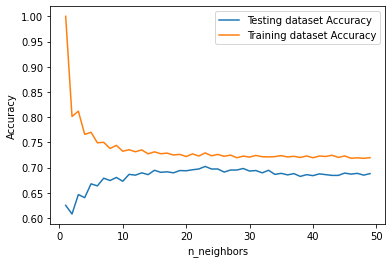

```python
neighbors = np.arange(1, 50)
train_accuracy = np.empty(len(neighbors))
test_accuracy = np.empty(len(neighbors))
for i, k in enumerate(neighbors):
    knn = KNeighborsClassifier(n_neighbors=k)
    knn.fit(X_train_t_tr, Y_train_t_tr)

    # Compute training and test data accuracy
    train_accuracy[i] = knn.score(X_train_t_tr, Y_train_t_tr)
    test_accuracy[i] = knn.score(X_train_t_val, Y_train_t_val)

# Generate plot
plt.plot(neighbors, test_accuracy, label = 'Testing dataset Accuracy')
plt.plot(neighbors, train_accuracy, label = 'Training dataset Accuracy')

plt.legend()
plt.xlabel('n_neighbors')
plt.ylabel('Accuracy')
plt.show()
```

```python
knn_model = KNeighborsClassifier(n_neighbors=12).fit(X_train_t_tr, Y_train_t_tr)

knn_train_accuracy=knn_model.score(X_train_t_tr, Y_train_t_tr)
knn_val_accuracy=knn_model.score(X_train_t_val, Y_train_t_val)
print('Train accuracy (KNN): %.3f'%knn_train_accuracy)
print('Validation accuracy (KNN): %.3f'%knn_val_accuracy)
```

```
Train accuracy (KNN): 0.732
Validation accuracy (KNN): 0.685
```

```python
knn_model = KNeighborsClassifier(n_neighbors=25).fit(X_train_t_tr, Y_train_t_tr)

knn_train_accuracy=knn_model.score(X_train_t_tr, Y_train_t_tr)
knn_val_accuracy=knn_model.score(X_train_t_val, Y_train_t_val)
print('Train accuracy (KNN): %.3f'%knn_train_accuracy)
print('Validation accuracy (KNN): %.3f'%knn_val_accuracy)
```

```
Train accuracy (KNN): 0.726
Validation accuracy (KNN): 0.697
```

### Polynomial Kernel SVM

```python
from sklearn.svm import SVC
svm_p = SVC(kernel='poly', degree=3).fit(X_train_t_tr, Y_train_t_tr)

svm_p_train_accuracy=svm_p.score(X_train_t_tr, Y_train_t_tr)
svm_p_val_accuracy=svm_p.score(X_train_t_val, Y_train_t_val)
print('Train accuracy (SVM_P): %.3f'%svm_p_train_accuracy)
print('Validation accuracy (SVM_P): %.3f'%svm_p_val_accuracy)
```

```
Train accuracy (SVM_P): 0.737
Validation accuracy (SVM_P): 0.725
```

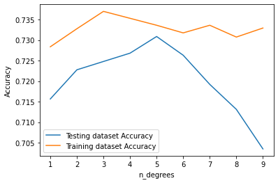

```python
degrees = np.arange(1, 10)
train_accuracy = np.empty(len(degrees))
test_accuracy = np.empty(len(degrees))
for i, k in enumerate(degrees):
    svm_p_temp = SVC(kernel='poly', degree=k).fit(X_train_t_tr, Y_train_t_tr)

    # Compute training and test data accuracy
    train_accuracy[i] = svm_p_temp.score(X_train_t_tr, Y_train_t_tr)
    test_accuracy[i] = svm_p_temp.score(X_train_t_val, Y_train_t_val)


# Generate plot
plt.plot(degrees, test_accuracy, label = 'Testing dataset Accuracy')
plt.plot(degrees, train_accuracy, label = 'Training dataset Accuracy')

plt.legend()
plt.xlabel('n_degrees')
plt.ylabel('Accuracy')
plt.show()
```

### Radial Basis Function (RBF) Kernel SVM

```python
from sklearn.svm import SVC
svm_rbf = SVC(kernel='rbf').fit(X_train_t_tr, Y_train_t_tr)

svm_rbf_train_accuracy=svm_rbf.score(X_train_t_tr, Y_train_t_tr)
svm_rbf_val_accuracy=svm_rbf.score(X_train_t_val, Y_train_t_val)
print('Train accuracy (svm_rbf): %.3f'%svm_rbf_train_accuracy)
print('Validation accuracy (svm_rbf): %.3f'%svm_rbf_val_accuracy)
```

```
Train accuracy (svm_rbf): 0.735
Validation accuracy (svm_rbf): 0.717
```

## Test All Models

```python
import warnings
warnings.filterwarnings("ignore")

X_test_t=pipeline.fit_transform(X_test)
# X_test_t = scaler.transform(X_test_t)

print('Log. Reg. train accuracy: %.3f'%log_reg.score(X_train_t_tr, Y_train_t_tr))
print('Log. Reg. val accuracy: %.3f'%log_reg.score(X_train_t_val, Y_train_t_val))
print('Log. Reg. test accuracy: %.3f'%log_reg.score(X_test_t, Y_test))

print('\nLinear SVC train accuracy: %.3f'%svc.score(X_train_t_tr, Y_train_t_tr))
print('Linear SVC val accuracy: %.3f'%svc.score(X_train_t_val, Y_train_t_val))
print('Linear SVC test accuracy: %.3f'%svc.score(X_test_t, Y_test))

print('\nNaive Bayes train accuracy: %.3f'%nb.score(X_train_t_tr, Y_train_t_tr))
print('Naive Bayes val accuracy: %.3f'%nb.score(X_train_t_val, Y_train_t_val))
print('Naive Bayes test accuracy: %.3f'%nb.score(X_test_t, Y_test))

print('\nLDA train accuracy: %.3f'%lda.score(X_train_t_tr, Y_train_t_tr))
print('LDA val accuracy: %.3f'%lda.score(X_train_t_val, Y_train_t_val))
print('LDA test accuracy: %.3f'%lda.score(X_test_t, Y_test))

print('\nTrain accuracy (DT optimized): %.3f'%train_accuracy_DT_opt)
print('Validation accuracy (DT optimized): %.3f'%val_accuracy_DT_opt)
print('Test accuracy (DT optimized): %.3f'%dt_grid_search.score(X_test_t, Y_test))

print('\nTrain accuracy (RF optimized): %.3f'%train_accuracy_RF_opt)
print('Validation accuracy (RF optimized): %.3f'%val_accuracy_RF_opt)
print('Test accuracy (RF optimized): %.3f'%rf_grid_search.score(X_test_t, Y_test))

print('\nTrain accuracy (boosting): %.3f'%train_accuracy_boosting)
print('Validation accuracy (boosting): %.3f'%val_accuracy_boosting)
print('Test accuracy (boosting): %.3f'%clf_boosting.score(X_test_t, Y_test))

print('\nTrain accuracy (KNN): %.3f'%knn_train_accuracy)
print('Validation accuracy (KNN): %.3f'%knn_val_accuracy)
print('Test accuracy (KNN): %.3f'%knn_model.score(X_test_t, Y_test))

print('\nTrain accuracy (SVM_P): %.3f'%svm_p_train_accuracy)
print('Validation accuracy (SVM_P): %.3f'%svm_p_val_accuracy)
print('Test accuracy (SVM_P): %.3f'%svm_p.score(X_test_t, Y_test))

print('\nTrain accuracy (svm_rbf): %.3f'%svm_rbf_train_accuracy)
print('Validation accuracy (svm_rbf): %.3f'%svm_rbf_val_accuracy)
print('Test accuracy (svm_rbf): %.3f'%svm_rbf.score(X_test_t, Y_test))
```

```
Log. Reg. train accuracy: 0.740
Log. Reg. val accuracy: 0.739
Log. Reg. test accuracy: 0.738

Linear SVC train accuracy: 0.518
Linear SVC val accuracy: 0.528
Linear SVC test accuracy: 0.518

Naive Bayes train accuracy: 0.673
Naive Bayes val accuracy: 0.665
Naive Bayes test accuracy: 0.672

LDA train accuracy: 0.740
LDA val accuracy: 0.737
LDA test accuracy: 0.738

Train accuracy (DT optimized): 0.732
Validation accuracy (DT optimized): 0.697
Test accuracy (DT optimized): 0.697

Train accuracy (RF optimized): 0.734
Validation accuracy (RF optimized): 0.736
Test accuracy (RF optimized): 0.733

Train accuracy (boosting): 0.746
Validation accuracy (boosting): 0.740
Test accuracy (boosting): 0.736

Train accuracy (KNN): 0.726
Validation accuracy (KNN): 0.697
Test accuracy (KNN): 0.708

Train accuracy (SVM_P): 0.737
Validation accuracy (SVM_P): 0.725
Test accuracy (SVM_P): 0.729

Train accuracy (svm_rbf): 0.735
Validation accuracy (svm_rbf): 0.717
Test accuracy (svm_rbf): 0.729
```

## Feature Selection

### Log_reg

```python
log_features = (X_train_t_val* log_reg.coef_[0]).mean().abs().sort_values(ascending=False)
log_features = log_features[log_features>0.2]
log_features = log_features.drop(labels = ["MaxDelqEver", "NumInqLast6Mexcl7days"])
print(len(log_features))
log_features
```

```
11
```

```
ExternalRiskEstimate          1.681906
PercentTradesNeverDelq        1.398745
AverageMInFile                0.783591
NumSatisfactoryTrades         0.601709
NumInqLast6M                  0.523765
NetFractionRevolvingBurden    0.422501
PercentInstallTrades          0.345575
MaxDelq2PublicRecLast12M      0.308552
NumRevolvingTradesWBalance    0.259679
NetFractionInstallBurden      0.239799
MSinceMostRecentDelq          0.228728
dtype: float64
```

```python
log_features1 = (X_train_t_val* log_reg.coef_[0]).mean().abs()
log_features1 = log_features1[log_features1>0.2]
log_features1 = log_features1.drop(labels = ["MaxDelqEver", "NumInqLast6Mexcl7days"])
print(len(log_features1))
log_features1
```

```
11
```

```
ExternalRiskEstimate          1.681906
AverageMInFile                0.783591
NumSatisfactoryTrades         0.601709
PercentTradesNeverDelq        1.398745
MSinceMostRecentDelq          0.228728
MaxDelq2PublicRecLast12M      0.308552
PercentInstallTrades          0.345575
NumInqLast6M                  0.523765
NetFractionRevolvingBurden    0.422501
NetFractionInstallBurden      0.239799
NumRevolvingTradesWBalance    0.259679
dtype: float64
```

```python
for i in log_features1.index:
  tmax = df_all[i].max()
  tmin = df_all[i].min()
  tmean = df_all[i].mean()
  print(i,tmax, tmin, tmean)
```

```
ExternalRiskEstimate 94 -9 67.42575772062338
AverageMInFile 383 -9 73.8432928578258
NumSatisfactoryTrades 79 -9 19.42805239506645
PercentTradesNeverDelq 100 -9 86.66153551964815
MSinceMostRecentDelq 83 -9 6.762405583707811
MaxDelq2PublicRecLast12M 9 -9 4.928291423654269
PercentInstallTrades 100 -9 32.166459508557224
NumInqLast6M 66 -9 0.8681518309589827
NetFractionRevolvingBurden 232 -9 31.629888134620902
NetFractionInstallBurden 471 -9 39.15890620518214
NumRevolvingTradesWBalance 32 -9 3.1850081269719857
```

```python
log_features1.index
```

```
Index(['ExternalRiskEstimate', 'AverageMInFile', 'NumSatisfactoryTrades',
       'PercentTradesNeverDelq', 'MSinceMostRecentDelq',
       'MaxDelq2PublicRecLast12M', 'PercentInstallTrades', 'NumInqLast6M',
       'NetFractionRevolvingBurden', 'NetFractionInstallBurden',
       'NumRevolvingTradesWBalance'],
      dtype='object')
```

```python
xTrain = X_train[log_features.index]
xValid = X_test[log_features.index]
```

```python
from sklearn.model_selection import cross_val_score

log_reg_new = LogisticRegression(max_iter=10000, random_state=0).fit(xTrain, Y_train)
print('Log. Reg. train accuracy: %.3f'%log_reg_new.score(xTrain, Y_train))
print('Log. Reg. val accuracy: %.3f'%log_reg_new.score(xValid, Y_test))

cv_results_log_reg = cross_validate(log_reg_new, xTrain, Y_train, cv=5, return_estimator=True)
print('Logistic regresion - CV accuracy score %.3f'%cv_results_log_reg['test_score'].mean()) # this is their average value

print('Log. Reg. Original train accuracy: %.3f'%log_reg.score(X_train_t_tr, Y_train_t_tr))
print('Log. Reg. Original val accuracy: %.3f'%log_reg.score(X_train_t_val, Y_train_t_val))
print('Log. Reg. Original test accuracy: %.3f'%log_reg.score(X_test_t, Y_test))
```

```
Log. Reg. train accuracy: 0.726
Log. Reg. val accuracy: 0.732
Logistic regresion - CV accuracy score 0.727
Log. Reg. Original train accuracy: 0.740
Log. Reg. Original val accuracy: 0.739
Log. Reg. Original test accuracy: 0.738
```

### LDA

```python
lda_features = (X_train_t_val* lda.coef_[0]).mean().abs().sort_values(ascending=False)
lda_features = lda_features[lda_features>0.2]
lda_features = lda_features.drop(labels = ["NumInqLast6Mexcl7days", "MaxDelq2PublicRecLast12M"])
print(len(lda_features))
lda_features
```

```
11
```

```
ExternalRiskEstimate          2.505887
PercentTradesNeverDelq        0.890099
AverageMInFile                0.719375
NumSatisfactoryTrades         0.699379
NumInqLast6M                  0.493418
NetFractionRevolvingBurden    0.413940
PercentInstallTrades          0.332089
NumRevolvingTradesWBalance    0.257835
MSinceMostRecentDelq          0.244472
NetFractionInstallBurden      0.221550
MSinceMostRecentDelq=-7       0.213998
dtype: float64
```

```python
lda_new = LinearDiscriminantAnalysis().fit(xTrain, Y_train)
print('\nLDA train original accuracy: %.3f'%lda_new.score(xTrain, Y_train))
print('LDA val original accuracy: %.3f'%lda_new.score(xValid, Y_test))

cv_results_lda = cross_validate(lda_new, xTrain, Y_train, cv=5, return_estimator=True)
print('LDA - CV accuracy score %.3f'%cv_results_lda['test_score'].mean()) # this is their average value

print('\nLDA train original accuracy: %.3f'%lda.score(X_train_t_tr, Y_train_t_tr))
print('LDA val original accuracy: %.3f'%lda.score(X_train_t_val, Y_train_t_val))
print('LDA test original accuracy: %.3f'%lda.score(X_test_t, Y_test))
```

```
LDA train original accuracy: 0.727
LDA val original accuracy: 0.730
LDA - CV accuracy score 0.726

LDA train original accuracy: 0.740
LDA val original accuracy: 0.737
LDA test original accuracy: 0.738
```

```python
lda_new = LinearDiscriminantAnalysis().fit(xTrain, Y_train)
print('\nLDA train original accuracy: %.3f'%lda_new.score(xTrain, Y_train))
print('LDA val original accuracy: %.3f'%lda_new.score(xValid, Y_test))

cv_results_lda = cross_validate(lda_new, xTrain, Y_train, cv=5, return_estimator=True)
print('LDA - CV accuracy score %.3f'%cv_results_lda['test_score'].mean()) # this is their average value

print('\nLDA train original accuracy: %.3f'%lda.score(X_train_t_tr, Y_train_t_tr))
print('LDA val original accuracy: %.3f'%lda.score(X_train_t_val, Y_train_t_val))
print('LDA test original accuracy: %.3f'%lda.score(X_test_t, Y_test))
```

```
LDA train original accuracy: 0.727
LDA val original accuracy: 0.730
LDA - CV accuracy score 0.726

LDA train original accuracy: 0.740
LDA val original accuracy: 0.737
LDA test original accuracy: 0.738
```

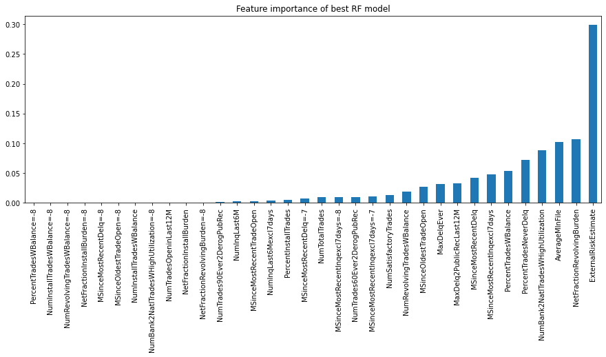

```python
pd.Series(data=rf_grid_search.best_estimator_.feature_importances_,
          index=column_names).sort_values().plot.bar(figsize=(15,5),
                                                     title='Feature importance of best RF model');
```

### RF

```python
rf_features = pd.Series(data=rf_grid_search.best_estimator_.feature_importances_,
          index=column_names).sort_values(ascending=False)
rf_features = rf_features[rf_features>0.02]
rf_features = rf_features.drop(labels = ["MaxDelqEver"])
print(len(rf_features))
rf_features
```

```
10
```

```
ExternalRiskEstimate                  0.299605
NetFractionRevolvingBurden            0.107358
AverageMInFile                        0.102667
NumBank2NatlTradesWHighUtilization    0.088432
PercentTradesNeverDelq                0.072489
PercentTradesWBalance                 0.053481
MSinceMostRecentInqexcl7days          0.047522
MSinceMostRecentDelq                  0.042043
MaxDelq2PublicRecLast12M              0.033276
MSinceOldestTradeOpen                 0.026868
dtype: float64
```

```python
param_grid = [{'n_estimators':[10,20,50],
               'max_depth':range(1,8),
               'min_samples_leaf':[10,20,100],
               'max_leaf_nodes':[2,4,8,16]}]

rf_grid_search_new = GridSearchCV(RandomForestClassifier(random_state=0),
                           param_grid,
                           cv=StratifiedKFold(n_splits=5, shuffle=True, random_state=0),
                           scoring='accuracy')

rf_grid_search_new.fit(xTrain, Y_train)
rf_accuracy_grid_new = pd.DataFrame(rf_grid_search_new.cv_results_)[['param_n_estimators', 'param_max_depth','param_max_leaf_nodes','param_min_samples_leaf','mean_test_score']]
rf_accuracy_grid_new.columns=['n_estimators','max_depth','max_leaf_nodes','min_samples_leaf','Accuracy']
print('BEST PARAM: \n', rf_grid_search_new.best_params_)
print('\nBEST MODEL: \n', rf_grid_search_new.best_estimator_)
rf_accuracy_grid_new.sort_values('Accuracy', ascending=False).head()
```

```
BEST PARAM:
 {'max_depth': 6, 'max_leaf_nodes': 16, 'min_samples_leaf': 100, 'n_estimators': 50}

BEST MODEL:
 RandomForestClassifier(max_depth=6, max_leaf_nodes=16, min_samples_leaf=100,
                       n_estimators=50, random_state=0)
```

|  | n_estimators | max_depth | max_leaf_nodes | min_samples_leaf | Accuracy |
| --- | --- | --- | --- | --- | --- |
| 215 | 50 | 6 | 16 | 100 | 0.724173 |
| 251 | 50 | 7 | 16 | 100 | 0.723159 |
| 176 | 50 | 5 | 16 | 20 | 0.723158 |
| 208 | 20 | 6 | 16 | 10 | 0.722779 |
| 179 | 50 | 5 | 16 | 100 | 0.722652 |

```python
train_accuracy_RF_opt_new = rf_grid_search_new.score(xTrain, Y_train)
val_accuracy_RF_opt_new = rf_grid_search_new.score(xValid, Y_test)

rf_new = RandomForestClassifier(max_depth=6, max_leaf_nodes=16, min_samples_leaf=100,
                       n_estimators=50, random_state=0).fit(X_train_t_tr, Y_train_t_tr)


print('Train accuracy (RF optimized): %.3f'%train_accuracy_RF_opt_new)
print('Validation accuracy (RF optimized): %.3f'%val_accuracy_RF_opt_new)
cv_results_rf = cross_validate(rf_new, xTrain, Y_train, cv=5, return_estimator=True)
print('RF - CV accuracy score %.3f'%cv_results_rf['test_score'].mean()) # this is their average value
```

[output not shown]

```python
print('\nTrain accuracy (RF optimized): %.3f'%train_accuracy_RF_opt)
print('Validation accuracy (RF optimized): %.3f'%val_accuracy_RF_opt)
print('Test accuracy (RF optimized): %.3f'%rf_grid_search.score(X_test_t, Y_test))
```

```
Train accuracy (RF optimized): 0.734
Validation accuracy (RF optimized): 0.736
Test accuracy (RF optimized): 0.733
```

```python
print('Log. Reg. train accuracy: %.3f'%log_reg_new.score(xTrain, Y_train))
print('Log. Reg. val accuracy: %.3f'%log_reg_new.score(xValid, Y_test))

cv_results_log_reg = cross_validate(log_reg_new, xTrain, Y_train, cv=5, return_estimator=True)
print('Logistic regresion - CV accuracy score %.3f'%cv_results_log_reg['test_score'].mean()) # this is their average value

print('\nLDA train original accuracy: %.3f'%lda_new.score(xTrain, Y_train))
print('LDA val original accuracy: %.3f'%lda_new.score(xValid, Y_test))

cv_results_lda = cross_validate(lda_new, xTrain, Y_train, cv=5, return_estimator=True)
print('LDA - CV accuracy score %.3f'%cv_results_lda['test_score'].mean()) # this is their average value

print('\nTrain accuracy (RF optimized): %.3f'%train_accuracy_RF_opt_new)
print('Validation accuracy (RF optimized): %.3f'%val_accuracy_RF_opt_new)
cv_results_rf = cross_validate(rf_new, xTrain, Y_train, cv=5, return_estimator=True)
print('RF - CV accuracy score %.3f'%cv_results_rf['test_score'].mean()) # this is their average value
```

```
Log. Reg. train accuracy: 0.726
Log. Reg. val accuracy: 0.732
Logistic regresion - CV accuracy score 0.727

LDA train original accuracy: 0.727
LDA val original accuracy: 0.730
LDA - CV accuracy score 0.726

Train accuracy (RF optimized): 0.730
Validation accuracy (RF optimized): 0.728
RF - CV accuracy score 0.721
```

Based on the CrossValidation accuracy, Logistic Regression performan the best, so we pick the model as the final one.

## Pickle Model

```python
filename = 'LG_Model'
outfile = open(filename,'wb')
pickle.dump(log_reg_new, outfile)
outfile.close()
```